# Clustering Travel Data and Text Mining News From Social Media

Julian Cuero

18/1/2021

### Travel reviews Clustering

#### Introduction

- The data used here is populated by crawling TripAdvisor.com.
- It contains 980 observations and 11 features.
- Reviews on destinations in 10 categories mentioned across East Asia are considered.
- Each traveler rating is mapped as follows: Excellent (4), Very Good (3), Average (2), Poor (1), and Terrible (0).
- Finally, average rating is used against each category per user.

## Data attributes

- **Attribute 1**: Unique user id
- **Attribute 2**: Average user feedback on art galleries
- **Attribute 3**: Average user feedback on dance clubs
- **Attribute 4**: Average user feedback on juice bars
- **Attribute 5**: Average user feedback on restaurants
- **Attribute 6**: Average user feedback on museums
- **Attribute 7**: Average user feedback on resorts
- **Attribute 8**: Average user feedback on parks/picnic spots
- **Attribute 9**: Average user feedback on beaches
- **Attribute 10**: Average user feedback on theaters
- **Attribute 11**: Average user feedback on religious institutions

#### Data Preparation

## Loading libraries

```r
library(ggplot2) # Make nice plots
library(factoextra) # Make plots for clusters
library(gridExtra) # Stack several plots
library(knitr) # Create html table
library(dplyr) # Data manipulation
library(tidyr) # Tidy Data
```

## Loading data

```r
reviews_data <- read.csv('https://archive.ics.uci.edu/ml/machine-learning-databases/00484/tripadvisor_review.csv')
```

**Rename columns according to attributes**

```r
new_names <- c('UserId', 'ArtGalleries', 'DanceClubs', 'JuiceBars',
               'Restaurants', 'Museums', 'Resorts', 'ParksPicnics',
               'Beaches', 'Theaters', 'Religious')
colnames(reviews_data) <- new_names
```

```r
reviews_data <- scale(reviews_data[,-1])
summary(reviews_data)
```

```
##   ArtGalleries       DanceClubs        JuiceBars        Restaurants
##  Min.   :-1.6922   Min.   :-2.8281   Min.   :-1.1201   Min.   :-1.3674
##  1st Qu.:-0.6827   1st Qu.:-0.5700   1st Qu.:-0.9426   1st Qu.:-0.4379
##  Median :-0.1933   Median :-0.1518   Median :-0.2451   Median :-0.1162
##  Mean   : 0.0000   Mean   : 0.0000   Mean   : 0.0000   Mean   : 0.0000
##  3rd Qu.: 0.3879   3rd Qu.: 0.4336   3rd Qu.: 0.7091   3rd Qu.: 0.1698
##  Max.   : 7.1175   Max.   : 4.7825   Max.   : 3.3054   Max.   :10.3939
##     Museums            Resorts          ParksPicnics       Beaches
##  Min.   :-2.01114   Min.   :-3.15621   Min.   :-2.676   Min.   :-3.0185
##  1st Qu.:-0.68522   1st Qu.:-0.70968   1st Qu.:-0.120   1st Qu.:-0.6913
##  Median :-0.09084   Median :-0.07951   Median :-0.120   Median :-0.1095
##  Mean   : 0.00000   Mean   : 0.00000   Mean   : 0.000   Mean   : 0.0000
##  3rd Qu.: 0.59499   3rd Qu.: 0.66187   3rd Qu.:-0.120   3rd Qu.: 0.5450
##  Max.   : 5.39576   Max.   : 3.55323   Max.   : 3.714   Max.   : 4.0358
##     Theaters          Religious
##  Min.   :-2.27474   Min.   :-2.05123
##  1st Qu.:-0.71151   1st Qu.:-0.80660
##  Median :-0.08074   Median :-0.05982
##  Mean   : 0.00000   Mean   : 0.00000
##  3rd Qu.: 0.52262   3rd Qu.: 0.74919
##  Max.   : 4.38955   Max.   : 2.67837
```

#### Modeling

### K-means clustering

**Trying k = 2**

```r
set.seed(44)
kmReviews <- kmeans(reviews_data, centers = 2)
```

##### Plotting clusters

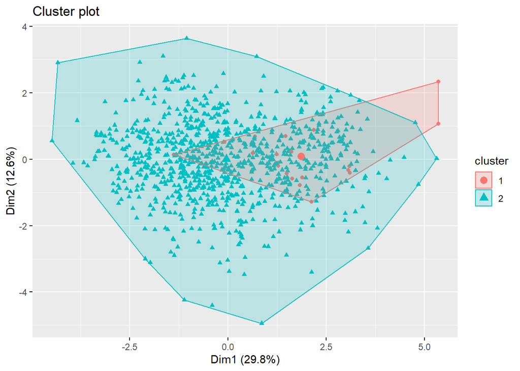

```r
fviz_cluster(kmReviews, data = reviews_data, geom = 'point')
```

#### Select best k

```r
k_values <- seq(2, 10, 1)

set.seed(668822544)
withins_sum <- sapply(k_values, function(k){
    kmeans(reviews_data, centers = k, nstart = 25)$tot.withinss
})
```

**“Elbow” method - Pick the k that has the largest decrease in the within clusters sum of squares (wcss).**

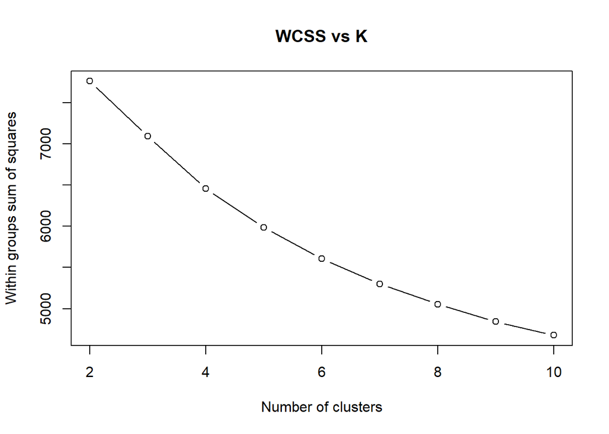

```r
plot(k_values, withins_sum, type='b', xlab="Number of clusters", ylab="Within groups sum of squares", main="WCSS vs K")
```

**It seems like a good choice of k is between 3 and 6.** Trying k-means with these different values since the plot does not show a clear minimum.

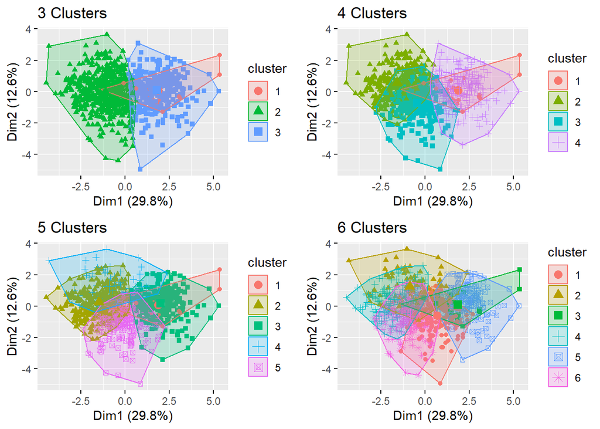

```r
set.seed(668822544)
km3 <- kmeans(reviews_data, centers = 3, nstart = 25)
km4 <- kmeans(reviews_data, centers = 4, nstart = 25)
km5 <- kmeans(reviews_data, centers = 5, nstart = 25)
km6 <- kmeans(reviews_data, centers = 6, nstart = 25)

p3 <- fviz_cluster(km3, reviews_data, geom='point') + ggtitle("3 Clusters")
p4 <- fviz_cluster(km4, reviews_data, geom='point') + ggtitle("4 Clusters")
p5 <- fviz_cluster(km5, reviews_data, geom='point') + ggtitle("5 Clusters")
p6 <- fviz_cluster(km6, reviews_data, geom='point') + ggtitle("6 Clusters")

grid.arrange(p3, p4, p5, p6, ncol = 2)
```

**With k=6 there is a higher between cluster sum of squares** which means that each cluster is very different to each other, which is good.

```r
btw_df <- data.frame(k = 3:6, betweenss = sapply(list(km3, km4, km5, km6), function(km) km$betweenss))
kable(btw_df)
```

| k | betweenss |
| --- | --- |
| 3 | 2699.348 |
| 4 | 3333.904 |
| 5 | 3804.358 |
| 6 | 4184.636 |

However, by looking at the decrease in wccs, it seems that **k=4 is a reasonable choice**. We don’t want too many or too few clusters for this problem and there aren’t that many travel categories (just 10).

```r
kable(data.frame(k=3:10, wcss_decrease=round(abs(diff(withins_sum)), 2)))
```

| k | wcss_decrease |
| --- | --- |
| 3 | 668.82 |
| 4 | 634.00 |
| 5 | 471.01 |
| 6 | 380.28 |
| 7 | 304.23 |
| 8 | 245.95 |
| 9 | 213.39 |
| 10 | 163.04 |

**Checking cluster means for scaled data**

```r
km4_centers <- as.data.frame(round(km4$centers, 3))
km4_centers <- km4_centers %>% gather(Activity, Value)
km4_centers$Cluster <- rep(paste0("Cluster", " ", 1:4), 10)
km4_centers <- arrange(km4_centers, Activity)
```

#### Interpreting clusters

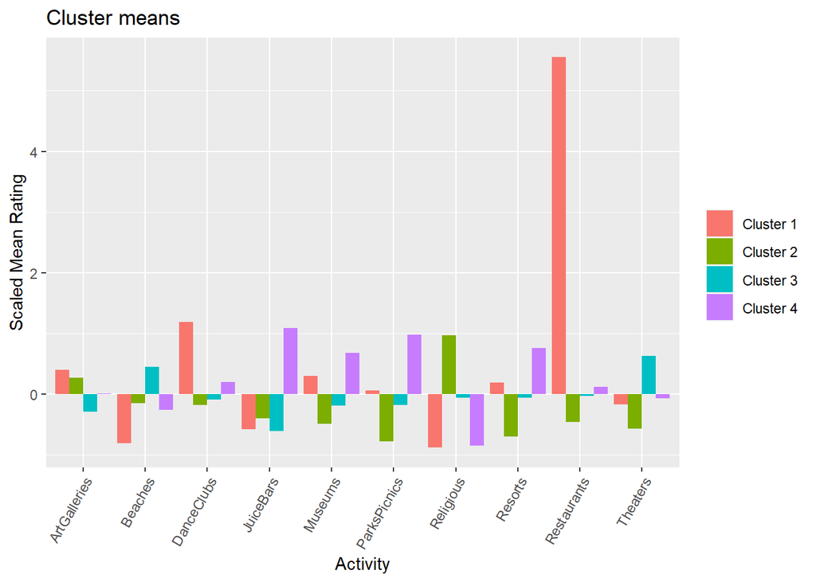

```r
ggplot(km4_centers, aes(Activity, Value, group=Cluster, fill=Cluster)) +
    geom_bar(stat="identity", position = position_dodge()) +
    theme(axis.text.x = element_text(hjust = 1, angle = 60)) +
    labs(y = "Scaled Mean Rating", fill="") +
    ggtitle("Cluster means")
```

### Hierarchical clustering

**Get euclidean distance matrix**

```r
distances <- dist(reviews_data, method = "euclidean")
```

**Perform hierarchical clustering with Wards method.**

```r
reviews.hclust <- hclust(distances, method = "ward.D")
```

**Plot dendrogram**

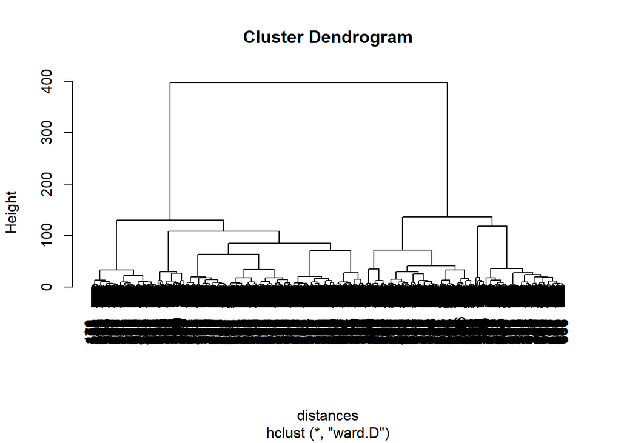

```r
plot(reviews.hclust)
```

**Cut dendrogram/tree to obtain 4 clusters**

```r
reviews.hclusters <- cutree(reviews.hclust, k=4)
```

**Split data by cluster**

```r
spl <- split(as.data.frame(reviews_data), reviews.hclusters)

hclustDf <- as.data.frame(round(sapply(spl, colMeans), 3))
names(hclustDf) <- c("Cluster1", "Cluster2", "Cluster3", "Cluster4")
hclustDf$Activity <- rownames(hclustDf)

# Delete row names
rownames(hclustDf) <- NULL

# Reorder columns
hclustDf <- hclustDf[,c(5, 1:4)]
hclustDf <- gather(hclustDf, Cluster, Value, -Activity) %>% arrange(Activity)
```

### Interpreting clusters

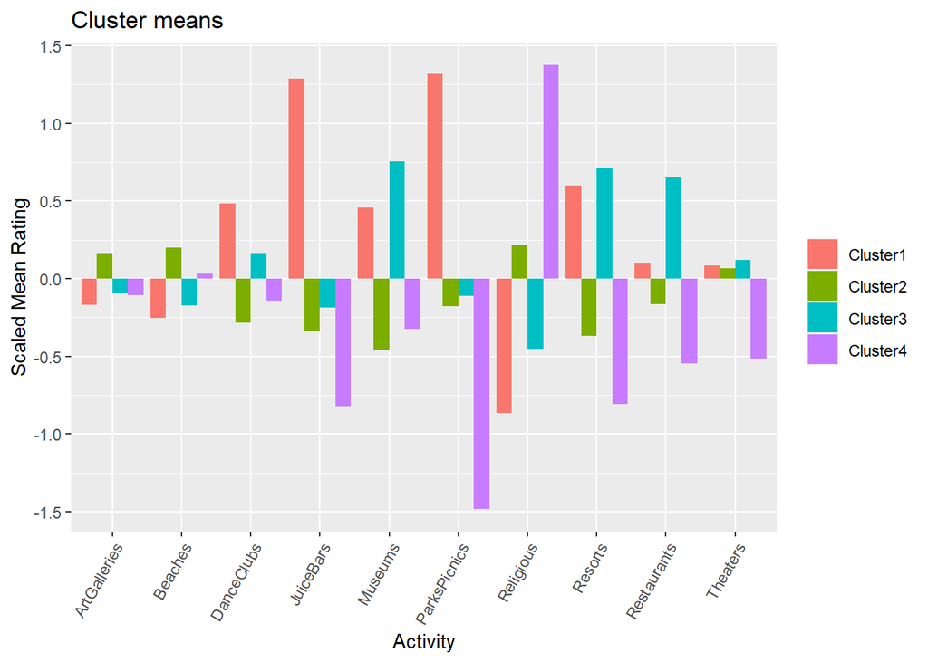

```r
ggplot(hclustDf, aes(Activity, Value, group=Cluster, fill=Cluster)) +
    geom_bar(stat="identity", position = position_dodge()) +
    theme(axis.text.x = element_text(hjust = 1, angle = 60)) +
    labs(y = "Scaled Mean Rating", fill="") +
    ggtitle("Cluster means")
```

### Conclusions

This data exploration showed that the output from both k-means and hierarchical clustering or other clustering methods don’t necessarily have to agree with each other. However **the methods used here clearly distinguished the group that was more devoted to religion and managed to make each group different to each other**.

### Reference

- Renjith, Shini, A. Sreekumar, and M. Jathavedan. 2018. *Evaluation of Partitioning Clustering Algorithms for Processing Social Media Data in Tourism Domain*. In 2018 IEEE Recent Advances in Intelligent Computational Systems (RAICS), 12731. IEEE.

### Online News Feeds Text mining

#### Introduction

- This data set corresponds to a series of news items and their respective social feedback on multiple platforms: Facebook, Google+ and LinkedIn.
- The collected data relates to a period of 8 months, between November 2015 and July 2016, accounting for about 100,000 news items on four different topics: **economy**, **microsoft**, **obama** and **palestine**.
- In this case, a random sample from the data is collected.

## Variables description

| Variable | Description |
| --- | --- |
| IDLink (numeric) | Unique identifier of news items |
| Title (string) | Title of the news item according to the official media sources |
| Headline (string) | Headline of the news item according to the official media sources |
| Source (string) | Original news outlet that published the news item |
| Topic (string) | Query topic used to obtain the items in the official media sources |
| PublishDate (timestamp) | Date and time of the news items publication |
| SentimentTitle (numeric) | Sentiment score of the text in the news items title |
| SentimentHeadline (numeric) | Sentiment score of the text in the news items headline |
| Facebook (numeric) | Final value of the news items popularity according to the social media source Facebook |
| GooglePlus (numeric) | Final value of the news items popularity according to the social media source Google+ |
| LinkedIn (numeric) | Final value of the news items popularity according to the social media source LinkedIn |

#### Data Preparation

## Loading packages

```r
library(tm) # Text mining
library(SnowballC) # Word Stemming
library(caret) # Split data into train and test sets
library(lubridate) # Handle dates
library(tidyverse) # Data manipulation, plotting, etc.
library(glmnet) # Lasso regression
library(adabag) # Boosting for classification trees
library(ipred) # Bagging for regression trees
```

## Loading data

```r
news_data <- read.csv("https://archive.ics.uci.edu/ml/machine-learning-databases/00432/Data/News_Final.csv",
                      stringsAsFactors = FALSE)
```

**Remove `Id` column**

```r
news_data <- news_data[, -1]
```

**Set system to english for current session**

```r
Sys.setlocale("LC_ALL", "C")
```

```
## [1] "C"
```

**Take smaller subset/sample from original data file.**

```r
set.seed(441110560)
index <- sample(nrow(news_data), nrow(news_data)*0.25, replace = FALSE)
news_data <- news_data[index,]
```

### Basic data wrangling

- Convert `Topic` to factor.
- Don’t perform the previous operation for Headline and Title since they are required to be characters for later.
- Create day of the week feature (`WeekDay`).

```r
news_data <- mutate(news_data,
                    PublishDate = ymd_hms(PublishDate),
                    Topic = as.factor(Topic),
                    Source = as.factor(Source),
                    WeekDay = weekdays(PublishDate))
```

- Convert `WeekDay` to factor

```r
news_data$WeekDay <- as.factor(news_data$WeekDay)
```

- Get years from 2015 to 2016

```r
news_data <- subset(news_data, year(PublishDate) %in% 2015:2016)
```

**Sentiment title distribution by day of the week** - There seems to be no influence in the day of the week on the news sentiment.

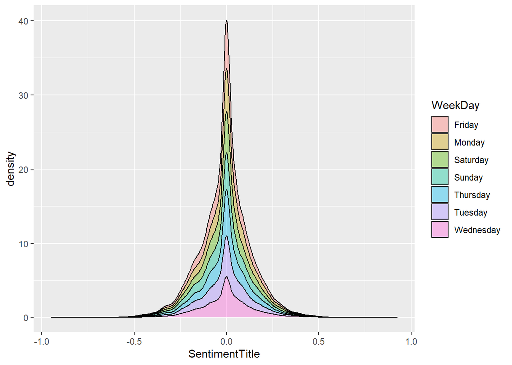

```r
news_data %>% ggplot(aes(x = SentimentTitle, group = WeekDay, fill = WeekDay)) +
    geom_density(position = "stack", alpha = 0.4)
```

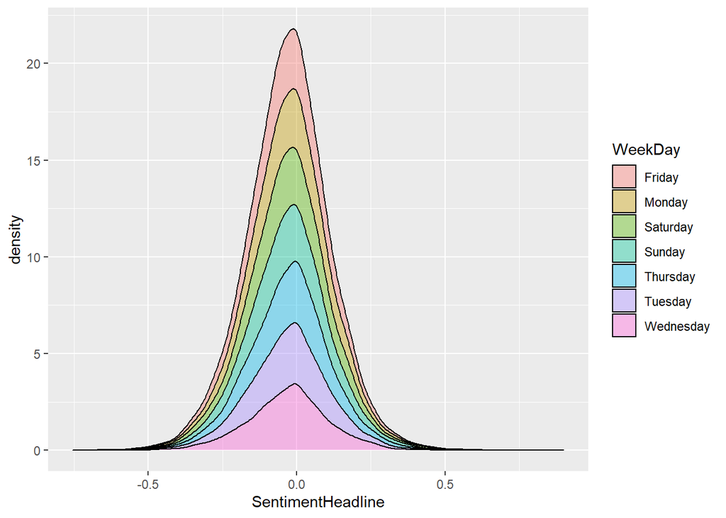

```r
news_data %>% ggplot(aes(x = SentimentHeadline, group = WeekDay, fill = WeekDay)) +
    geom_density(position = "stack", alpha = 0.4)
```

Helper function `makeCorpus` to create and perform basic cleaning for corpus.

```r
makeCorpus <- function(var){
    # Convert var to corpus
    corpus <- VCorpus(VectorSource(var))
    # Convert documents to lowercase
    corpus = tm_map(corpus, content_transformer(tolower))
    # Remove punctuation
    corpus = tm_map(corpus, removePunctuation)
    # Remove stop words (words like the, I, etc)
    corpus <- tm_map(corpus, removeWords, stopwords('english'))
    # Stem documents (represent words with different endings as the same word)
    corpus <- tm_map(corpus, stemDocument)
    # Return corpus
    corpus
}
```

**Corpus for `Title` variable**

```r
titleCorpus <- makeCorpus(news_data$Title)
```

**Create word frequency matrix**

```r
frequencies <- DocumentTermMatrix(titleCorpus)
frequencies
```

```
## <<DocumentTermMatrix (documents: 23309, terms: 13617)>>
## Non-/sparse entries: 151078/317247575
## Sparsity           : 100%
## Maximal term length: 26
## Weighting          : term frequency (tf)
```

**Inspect matrix**

```r
inspect(frequencies[10:14, 2000:2003])
```

```
## <<DocumentTermMatrix (documents: 5, terms: 4)>>
## Non-/sparse entries: 0/20
## Sparsity           : 100%
## Maximal term length: 5
## Weighting          : term frequency (tf)
## Sample             :
##     Terms
## Docs bmws bnm boao board
##   10    0   0    0     0
##   11    0   0    0     0
##   12    0   0    0     0
##   13    0   0    0     0
##   14    0   0    0     0
```

**Take a look at the most frequent words (that appear at least 500 times).**

```r
findFreqTerms(frequencies, lowfreq = 500)
```

```
##  [1] "2016"      "china"     "econom"    "economi"   "global"    "microsoft"
##  [7] "new"       "obama"     "palestin"  "presid"    "say"       "will"
## [13] "window"
```

Not surprisingly, the **words that appear more often are related to the news topics**.

```r
table(news_data$Topic)
```

```
##
##   economy microsoft     obama palestine
##      8557      5479      7101      2172
```

**Get rid of sparse terms that don’t appear very often** - **Keep terms that are present by at least 1% or more in the news titles**.

```r
sparse.title <- removeSparseTerms(frequencies, 0.99)
sparse.title
```

```
## <<DocumentTermMatrix (documents: 23309, terms: 59)>>
## Non-/sparse entries: 40367/1334864
## Sparsity           : 97%
## Maximal term length: 11
## Weighting          : term frequency (tf)
```

**Convert to data frame (df)**

```r
sparseTitles <- as.data.frame(as.matrix(sparse.title))
```

**Change names to convey R standards**

```r
names(sparseTitles) <- make.names(names(sparseTitles))
```

**Add dependent variable**

```r
sparseTitles <- sparseTitles %>%
    mutate(SentimentTitle = news_data$SentimentTitle)
```

**Since this process will be repeated for the `Headline` column, two more helper functions are created**:

- `getDtm`: Create document term matrix (dtm).

```r
getDtm <- function(corpus, sparseness=.99){
    removeSparseTerms(DocumentTermMatrix(corpus), sparseness)
}
```

- `asDf`: Convert from dtm to df.

```r
asDf <- function(dtm, outcome){
    df <- as.data.frame(as.matrix(dtm))
    # Friendly names
    colnames(df) <- make.names(colnames(df))
    # Append outcome
    df[, c(outcome)] <- news_data[, c(outcome)]

    df
}
```

#### Regression

### Regression for news title sentiment

**Split data**: 60% to train set and the rest for testing.

```r
set.seed(1203160122)
train_index.title <- createDataPartition(sparseTitles$SentimentTitle, times = 1, p = 0.6, list = FALSE)
trainTitles <- sparseTitles[train_index.title,]
testTitles <- sparseTitles[-train_index.title,]
```

### Lasso regression (Apply L1 Penalty for large coefficients)

Pass x matrix of predictors and y vector because `glmnet` does not take data frame as input **alpha = 1 provides Lasso penalty**.

```r
lasso_fit <- glmnet(x = as.matrix(trainTitles[, -c(which(colnames(trainTitles) == 'SentimentTitle'))]),
                    y = trainTitles$SentimentTitle,
                    alpha = 1)
```

**Lambda = 0.01** - Lower Lambda values gives higher coefficients.

```r
coef(lasso_fit, s = 0.01)
```

```
## 60 x 1 sparse Matrix of class "dgCMatrix"
##                        1
## (Intercept) -0.005796573
## X2016        .
## app          .
## back         0.003143269
## bank         .
## barack       .
## boost        .
## brexit       .
## busi         .
## call         .
## can          .
## china        0.021419408
## clinton      .
## cloud        .
## court        0.144839942
## data         .
## econom       .
## economi      .
## first        0.019540219
## get          .
## global       .
## grow         .
## growth      -0.073788373
## gun          .
## help         .
## hous         .
## india        .
## israel       .
## job          .
## make         .
## market       .
## may          .
## meet         .
## microsoft    .
## new          .
## now          .
## obama        .
## one          .
## palestin     .
## palestinian  .
## plan         .
## presid       .
## rate         .
## report       .
## say          .
## share        .
## show         .
## state        .
## support     -0.014206188
## surfac       0.021327171
## take         .
## trump        .
## updat        .
## visit        .
## white        .
## will         .
## window       .
## world        .
## xbox         .
## year         .
```

**Lambda = 5** - Increasing Lambda provides smaller coefficients.

```r
coef(lasso_fit, s = 5)
```

```
## 60 x 1 sparse Matrix of class "dgCMatrix"
##                        1
## (Intercept) -0.004791821
## X2016        .
## app          .
## back         .
## bank         .
## barack       .
## boost        .
## brexit       .
## busi         .
## call         .
## can          .
## china        .
## clinton      .
## cloud        .
## court        .
## data         .
## econom       .
## economi      .
## first        .
## get          .
## global       .
## grow         .
## growth       .
## gun          .
## help         .
## hous         .
## india        .
## israel       .
## job          .
## make         .
## market       .
## may          .
## meet         .
## microsoft    .
## new          .
## now          .
## obama        .
## one          .
## palestin     .
## palestinian  .
## plan         .
## presid       .
## rate         .
## report       .
## say          .
## share        .
## show         .
## state        .
## support      .
## surfac       .
## take         .
## trump        .
## updat        .
## visit        .
## white        .
## will         .
## window       .
## world        .
## xbox         .
## year         .
```

#### Pick the optimal value for lambda with 5-fold cross validation

**Reiterating**:

- **Higher values** for lambda **means higher penalty for coefficients** (which may lead to oversmoothing).
- **Lower values may lead to overfitting** because we would be closer to just to the original objective (minimize RMSE). Therefore, is useful to find the best tuning parameter.

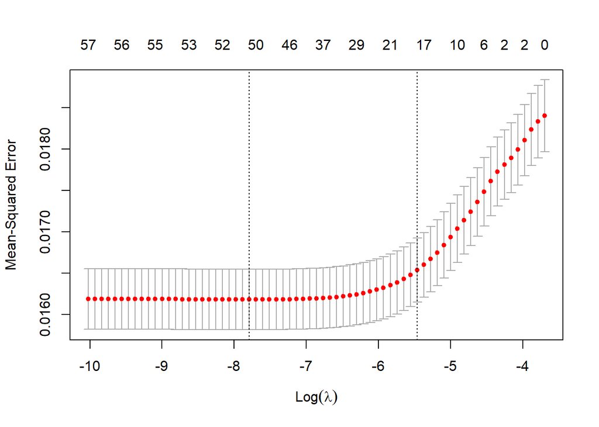

```r
cv_lasso.title <- cv.glmnet(x = as.matrix(trainTitles[, -c(which(colnames(trainTitles) == 'SentimentTitle'))]),
                            y = trainTitles$SentimentTitle,
                            alpha = 1,
                            nfolds = 5)
plot(cv_lasso.title)
```

**With this lambda value we may get a higher training error but this compensates with the model generalization in the test set (better prediction accuracy)**.

```r
# Best lambda (or s) that minimized error on validation set
cv_lasso.title$lambda.min
```

```
## [1] 0.0004139912
```

Make predictions on test set for the selected lambda

```r
preds.title <- predict(lasso_fit,
                       as.matrix(testTitles[, -c(which(colnames(testTitles) == 'SentimentTitle'))]),
                       s = cv_lasso.title$lambda.min)
```

**Another helper function to calculate RMSE**.

```r
RMSE <- function(pred, label){
    sqrt(mean((pred - label)^2))
}
```

**RMSE on train set** = **0.12667**

```r
preds.title.train <- predict(lasso_fit,
                             as.matrix(trainTitles[, -c(which(colnames(trainTitles) == 'SentimentTitle'))]),
                             s = cv_lasso.title$lambda.min)
RMSE(as.vector(preds.title.train), trainTitles$SentimentTitle)
```

```
## [1] 0.12667
```

**RMSE on testing** = **0.1259853**

```r
RMSE(as.vector(preds.title), testTitles$SentimentTitle)
```

```
## [1] 0.1259853
```

### Bagging

**Fit a tree for each bootstrap sample, and then aggregate the predicted values from all these trees**.

```r
bagged.title <- bagging(SentimentTitle ~ ., data = trainTitles, nbagg=100)
bagged.title
```

```
##
## Bagging regression trees with 100 bootstrap replications
##
## Call: bagging.data.frame(formula = SentimentTitle ~ ., data = trainTitles,
##     nbagg = 100)
```

**RMSE on train set** = **0.131326**

```r
RMSE(predict(bagged.title), trainTitles$SentimentTitle)
```

```
## [1] 0.131326
```

**Predict on test set**

```r
bag.pred.title <- predict(bagged.title, newdata = testTitles)
```

**RMSE on test set** = **0.1303784**

```r
RMSE(bag.pred.title, testTitles$SentimentTitle)
```

```
## [1] 0.1303784
```

#### Corpus for headlines

```r
headlineCorpus <- makeCorpus(news_data$Headline)
sparse.headline <- getDtm(headlineCorpus)
sparseHeadlines <- asDf(sparse.headline, "SentimentHeadline")
```

**Split data**

```r
set.seed(1203160122)
train_index.headline <- createDataPartition(sparseHeadlines$SentimentHeadline, times = 1, p = 0.6, list = FALSE)
trainHeadlines <- sparseHeadlines[train_index.headline,]
testHeadlines <- sparseHeadlines[-train_index.headline,]
```

### Regression for news headline sentiment

```r
lasso.headlines <- glmnet(x=as.matrix(trainHeadlines[, -c(which(colnames(trainHeadlines) == "SentimentHeadline"))]), y=trainHeadlines$SentimentHeadline, alpha = 1, numFolds=5)
```

**RMSE train** = **0.1300101**

```r
pred.headlines.train <- predict(lasso.headlines,
                          as.matrix(trainHeadlines[, -c(which(colnames(trainHeadlines) == "SentimentHeadline"))]),
                          s = lasso.headlines$lambda.min)
RMSE(pred.headlines.train, trainHeadlines$SentimentHeadline)
```

```
## [1] 0.1300101
```

**RMSE test** = **0.1322504**

```r
pred.headlines.test <- predict(lasso.headlines,
                       as.matrix(testHeadlines[, -c(which(colnames(testHeadlines) == 'SentimentHeadline'))]),
                       s = lasso.headlines$lambda.min)
RMSE(pred.headlines.test, testHeadlines$SentimentHeadline)
```

```
## [1] 0.1322504
```

#### Classification

### Classifying news topics

**Remove outcomes**

```r
sparseTitles$SentimentTitle <- NULL
sparseHeadlines$SentimentHeadline <- NULL
```

**Change columns names of sparse dataframes for both titles and headlines**.

```r
colnames(sparseTitles) <- paste0("T", colnames(sparseTitles))
colnames(sparseHeadlines) <- paste0("H", colnames(sparseHeadlines))
```

**Join Title and Headline sparseMatrix as features**.

```r
final_data <- cbind(news_data, sparseTitles, sparseHeadlines)
final_data <- select(final_data, -c(Title, Headline, Source, PublishDate, WeekDay, SentimentTitle, SentimentHeadline))
```

**Split data**

```r
set.seed(882)
train_index <- createDataPartition(final_data$Topic, times = 1, p = 0.6, list = FALSE)
final_data.train <- final_data[train_index,]
final_data.test <- final_data[-train_index,]
```

### 10 Nearest Neighbor

```r
knn.topic <- knn3(Topic ~., data=final_data.train, k=10)
```

Since there is no higher cost involved when predicting false positives or false negatives (**we care about specificity and sensitivity equally**), accuracy serves as a good measure of model performance.

- **Accuracy on train set** = **0.89**

```r
confusionMatrix(predict(knn.topic, final_data.train, type="class"),
                final_data.train$Topic)
```

```
## Confusion Matrix and Statistics
##
##            Reference
## Prediction  economy microsoft obama palestine
##   economy      4520       234   159        35
##   microsoft     198      2841    58        11
##   obama         336       141  4026       191
##   palestine      81        72    18      1067
##
## Overall Statistics
##
##                Accuracy : 0.8903
##                  95% CI : (0.885, 0.8955)
##     No Information Rate : 0.3671
##     P-Value [Acc > NIR] : < 2.2e-16
##
##                   Kappa : 0.845
##
##  Mcnemar's Test P-Value : < 2.2e-16
##
## Statistics by Class:
##
##                      Class: economy Class: microsoft Class: obama
## Sensitivity                  0.8802           0.8641       0.9448
## Specificity                  0.9517           0.9750       0.9313
## Pos Pred Value               0.9135           0.9141       0.8577
## Neg Pred Value               0.9320           0.9589       0.9747
## Prevalence                   0.3671           0.2351       0.3046
## Detection Rate               0.3231           0.2031       0.2878
## Detection Prevalence         0.3537           0.2222       0.3356
## Balanced Accuracy            0.9159           0.9195       0.9381
##                      Class: palestine
## Sensitivity                   0.81825
## Specificity                   0.98652
## Pos Pred Value                0.86187
## Neg Pred Value                0.98141
## Prevalence                    0.09322
## Detection Rate                0.07628
## Detection Prevalence          0.08850
## Balanced Accuracy             0.90238
```

**Test set accuracy** = **0.8702929**

```r
confusionMatrix(predict(knn.topic, final_data.test, type="class"),
                final_data.test$Topic)$overall["Accuracy"]
```

```
##  Accuracy
## 0.8702929
```

### Boosting

**Using 90 trees and bootstrapped samples**.

```r
boost.topic <- boosting(Topic ~., data=final_data.train, boost=TRUE, mfinal=90)
```

**Plotting variable importance according to boosting model** - The fact that the word Obama appears or not in the title (`Tobama`) influences the topic assignment.

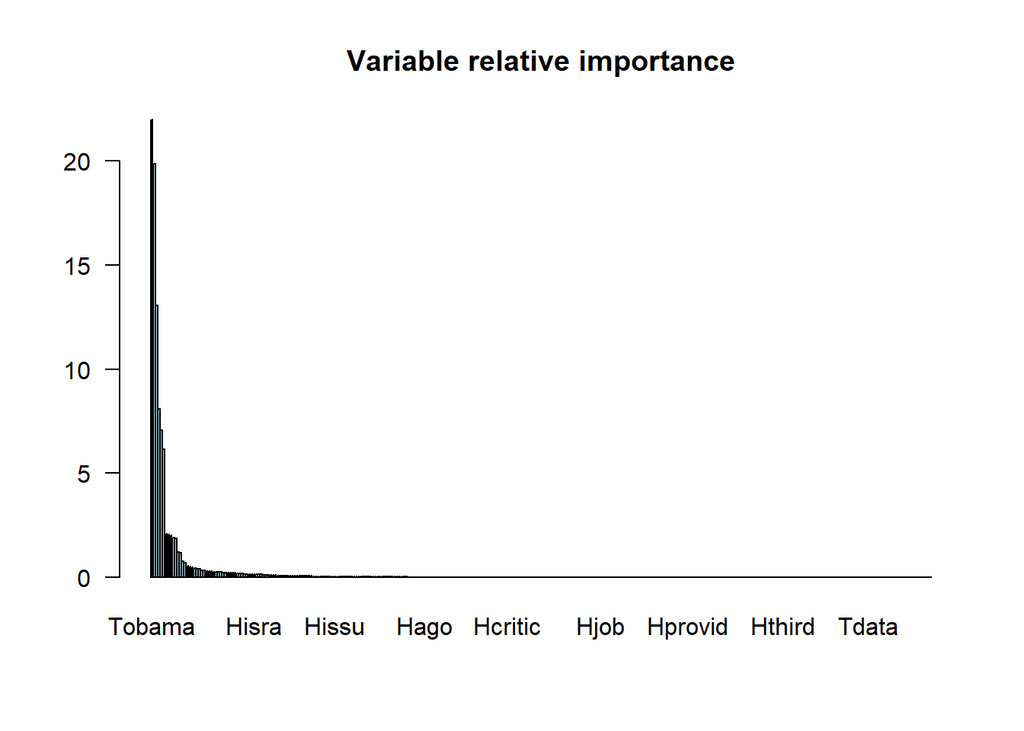

```r
importanceplot(boost.topic)
```

**Training Accuracy** = **0.993137**

```r
pred.boost.topic <- predict(boost.topic, final_data.train)
confusionMatrix(factor(pred.boost.topic$class), final_data.train$Topic)$overall["Accuracy"]
```

```
## Accuracy
## 0.993137
```

**Testing Accuracy** = **0.9897007**

```r
pred.boost.topic <- predict(boost.topic, final_data.test)
confusionMatrix(factor(pred.boost.topic$class), final_data.test$Topic)$overall["Accuracy"]
```

```
##  Accuracy
## 0.9897007
```

### Summary

In general, there is a relatively high accuracy. Boosting significantly outperformed KNN because it takes the average vote of many trees.

### Future Work

- **Try other classification models** like randomForest, CART, etc., as they might defeat boosting or provide better interpretation of variables.
- **Tune parameters** for both KNN and boosting for futures models. It seems that setting an arbitrary number of neighbors affected the KNN performance on new data (overfitting).
- Find a way to **plot the ROC Curve and get the AUC** for a multiclass classification problem like this one.

### Reference

- Nuno Moniz and Luís Torgo (2018), *Multi-Source Social Feedback of Online News Feeds*, CoRR, abs/1801.07055, [Web Link](https://archive.ics.uci.edu/ml/datasets/abs/1801.07055).